# CLL Cytokine Screen 2021: Figure 6

Holly Giles, Peter Bruch

12 November 2021

# 1 Figure 6

In this sub-vignette we present the analysis and source code for figure 6. This sub-vignette can be built along with all other sub-vignettes by running CLLCytokineScreen2021.Rmd.

## 1.1 Set up

```r
set.seed(1996)
```

Load libraries

```r
library(plyr)
library(dplyr)
library(ggpubr)
library(ggbeeswarm)
library(ggplot2)
library(data.table)
library(magrittr)
library(pheatmap)
library(gtable)
library(glmnet)
library(RColorBrewer)
library(gridExtra)
library(patchwork)
library(cowplot)
library(tidyverse)
```

Set plot directory

```r
plotDir = ifelse(exists(".standalone"), "", "../../inst/figs/")
if(plotDir!="") if(!file.exists(plotDir)) dir.create(plotDir)
```

## 1.2 Load data

Load raw files

```r
#df: tibblecontaining all screening viability data
load( "../../data/df.RData")

#patMeta: tibble containing all patient genetic data
load( "../../data/patMeta.RData")
```

```r
#From tsvs
#df: tibble containing all screening data
df <- read.table(file= "../../inst/extdata/df.txt",header = TRUE) %>% as_tibble()

#patMeta: tibble containing genetic data for patient samples in screen
patMeta <- read.table(file= "../../inst/extdata/patMeta.txt",header = TRUE) %>% as_tibble()



#Arrange data for analysis
#screening data
df$Cytokine <- factor(df$Cytokine, levels= c("No Cytokine",
                                              "Resiquimod",
                                              "IL-4",
                                              "TGF-b1",
                                              "IL-1b",
                                              "Interferon gamma",
                                              "SDF-1a",
                                              "sCD40L" ,
                                              "sCD40L+IL-4",
                                              "soluble anti-IgM",
                                              "CpG ODN",
                                              "IL-6",
                                              "IL-10",
                                              "IL-21",
                                              "HS-5 CM",
                                              "IL-15",
                                              "BAFF",
                                              "IL-2" ))



df$Drug <- factor(df$Drug, levels =c("DMSO",
                                     "BAY-11-7085",
                                     "Everolimus",
                                     "Fludarabine",
                                     "I-BET 762",
                                     "Ibrutinib","Idelalisib",
                                     "Luminespib",
                                     "Nutlin-3a",
                                     "PRT062607",
                                     "Pyridone-6",
                                     "Ralimetinib",
                                     "Selumetinib"))


#patMeta
patMeta %>% mutate_at(vars(-PatientID), as.factor)
```

Process data

```r
#only high concentrations of drugs
df <-
  dplyr::filter(df, Drug_Concentration %in% c("None","High")) %>%
  dplyr::select(PatientID, Drug, Cytokine, DCK, Log)

#rename columns
df <-
  plyr::rename(df,
               c("Drug"="treatment_drug",
                 "Cytokine"="treatment_cytokine",
                 "Log"="Viability"))
```

Define lists

```r
#lists for drug and cytokine treatments
thecytokines <- unique(df$treatment_cytokine) %>% setdiff("No Cytokine")
thedrugs <- unique(df$treatment_drug) %>% setdiff("DMSO")
```

## 1.3 Define aesthetics

```r
source("../../R/themes_colors.R")
```

## 1.4 Define Functions

*Run Glmnet function:* This function takes a feature matrix `X` of patient genetic features and a continuous response matrix `y`, containing the interaction coefficients for a given drug : stimulus combination, for each patient. The function runs lasso or ridge regularised regression, in order to identify genetic predictors of the size of an interaction between a drug and stimulus. The function will run the `cv.glmnet` function for the chosen number of `repeats`, applying cross-fold validation using chosen number of `folds`.

```r
#Function for multi-variant regression
runGlm <- function(X, y, method = "lasso", repeats = 20, folds = 3) {
  #set up objects to store results
  modelList <- list()
  lambdaList <- c()
  varExplain <- c()
  coefMat <- matrix(NA, ncol(X), repeats)
  rownames(coefMat) <- colnames(X)

  #set alpha
  if (method == "lasso"){
    alpha = 1
  } else if (method == "ridge") {
    alpha = 0
  }

  #for the set number of repeats, run the regression
  for (i in seq(repeats)) {
    if (ncol(X) > 2) {
      #run cross validated generalised linear model with given parameters
      res <- cv.glmnet(X,y, type.measure = "mse", family="gaussian",
                       nfolds = folds, alpha = alpha, standardize = FALSE)

      #store lamdas and min lambda value
      lambdaList <- c(lambdaList, res$lambda.min)

      #store result of cv.glmnet
      modelList[[i]] <- res

      #get coefficents with min lambda value
      coefModel <- coef(res, s = "lambda.min")[-1] #remove intercept row

      #store coefficients for this repeat
      coefMat[,i] <- coefModel

      #calculate variance explained
      if(sum(coefModel !=0)){
      y.pred <- predict(res, s = "lambda.min", newx = X)
      #if there are no predictors, all y.pred will be the same so its not possible to calculate variance explained because the SD is 0
      varExp <- cor(as.vector(y),as.vector(y.pred))^2
      }else{ varExp <- NA}
      varExplain[i] <- ifelse(is.na(varExp), 0, varExp)



    } else {
      fitlm<-lm(y~., data.frame(X))
      varExp <- summary(fitlm)$r.squared
      varExplain <- c(varExplain, varExp)

    }

  }
  #store all results
  list(modelList = modelList, lambdaList = lambdaList, varExplain = varExplain, coefMat = coefMat)
}
```

*lassoPlot* To generate predictor profiles to display outputs from `runGlm` function. Function takes `lassoOut`, a list of objects that is generated by running `runGlm`, plus the feature and response matrices (`geneMatrix` and `betaMatrix`), plus specifications for `freqCut`, the proportion of bootstrapped repeats that a coefficient should be significant for it to be included in the predictor plot, and `coefCut` , the minimum value of a coefficient for it to be included in the plot.

```r
lassoPlot <- function(lassoOut, geneMatrix, betaMatrix, freqCut = 1, coefCut = 0.01) {
  #object to hold all plots
  plotList <- list()

  #for each drug - stimuli combination, run the following:
  for (seaName in names(lassoOut)) {
    ###FOR THE BAR PLOT
    #extract mean coefficients for each drug - stimuli combination
    barValue <- rowMeans(lassoOut[[seaName]]$coefMat)
    #extract proportion of repeats for which each coefficient is significant
    freqValue <- rowMeans(abs(sign(lassoOut[[seaName]]$coefMat)))
    #filter out coefficients that don't meet freqCut and coefCut thresholds
    barValue <- barValue[abs(barValue) >= coefCut & freqValue >= freqCut]
    #arrange the bar values in numerical order
    barValue <- barValue[order(barValue)]
    #if there are no sig coefficients, don't plot
    if(length(barValue) == 0) {
      plotList[[seaName]] <- NA
      next
    }


    ###FOR THE HEATMAP AND SCATTER PLOT
    #get feature matrix and response matrix to plot
    allData <- geneMatrix
    betaValue <- unlist(betaMatrix[seaName,])

    #get feature matrix for features with significant coefficients only
    tabValue <- allData[, names(barValue),drop=FALSE]
    ord <- order(betaValue)
    betaValue <- betaValue[ord]
    tabValue <- tabValue[ord, ,drop=FALSE]
    sampleIDs <- rownames(tabValue)
    tabValue <- as_tibble(tabValue)
    tabValue$Sample <- sampleIDs

    #annotate features as mutations, methylation cluster or IGHV, and apply different scaling     so that different colours can be used in plotting

    #for mutations:
    matValue <- gather(tabValue, key = "Var",value = "Value", -Sample)
    matValue$Type <- "mut"

    #for methylation cluster
    matValue$Type[grep("Methylation",matValue$Var)] <- "meth"

    #for IGHV status
    matValue$Type[grep("IGHV.status",matValue$Var)] <- "ighv"

    #change the scale of the value so that IGHV, Methylation and Mutation do not overlap
    matValue[matValue$Type == "mut",]$Value = matValue[matValue$Type == "mut",]$Value + 10
    matValue[matValue$Type == "meth",]$Value = matValue[matValue$Type == "meth",]$Value + 20
    matValue[matValue$Type == "ighv",]$Value = matValue[matValue$Type == "ighv",]$Value + 30

    #change continous to catagorical
    matValue$Value <- factor(matValue$Value,levels = sort(unique(matValue$Value)))

    #arrange order of feature rows and columns in heatmap
    #heatmap rows should align with order of genetic coefficients
    matValue$Var <- factor(matValue$Var, levels = names(barValue))

    #sample columns should be ascending order according to value of coefficient of each patient, so that heatmap aligns with scatter plot below
    matValue$Sample <- factor(matValue$Sample, levels = names(betaValue))

    #update labels, keep factor levels
    matValue$Var <- revalue(matValue$Var, c("IGHV.status" = "IGHV status", "del11q" = "del(11q)", "del13q" = "del(13q)", "del17p" = "del(17p)", "trisomy12" = "trisomy 12"))

    #MAKE PLOTS
    #plot the heatmap of genetic feature values
    p1 <- ggplot(matValue, aes(x=Sample, y=Var)) +
      geom_tile(aes(fill=Value), color = "white") + #ghost white
      theme_bw()+
      scale_y_discrete(expand=c(0,0)) +
      theme(axis.title.x = element_text( size=fontsize+4),
            axis.text.y=element_text(hjust=0, size=18, face="bold"),
            axis.ticks=element_blank(),
            panel.border=element_rect(colour="gainsboro"),
            plot.title=element_text(face="bold", size = 18, margin = margin(t = -5, b = 1)),
            panel.background=element_blank(),
            panel.grid.major=element_blank(),
            panel.grid.minor=element_blank()) +
      xlab("Mutation status for each patient") +
      ylab("") +
      scale_fill_manual(name="Mutated",
                              values=c(`10`= offwhite,  #WT
                                       `11`="#373A36", #Mutant
                                       `20`= offwhite, #LP
                                       `20.5`= "#707372", #IP
                                       `21` = "#A8A99E", #HP
                                       `30` = offwhite, #IGHV-U
                                       `31` = "#707372"), #IGHV-M
                                       guide="none") +
            ggtitle(seaName)


    #Plot the bar plot on the left of the heatmap
    barDF = data.frame(barValue, nm=factor(names(barValue),levels=names(barValue)))

    p2 <- ggplot(data=barDF, aes(x=nm, y=barValue)) +
      geom_bar(stat="identity",
               fill=ifelse(barValue<0,
                           palblues[6],palreds[8]),
               colour="black",
               size=0.3) +
      scale_x_discrete(expand=c(0,0.5))+
      scale_y_continuous(expand=c(0,0), n.breaks = 4)+
      coord_flip(ylim=c(-0.3,0.35))+
      theme(panel.grid.major=element_blank(),
            panel.background=element_blank(),
            axis.ticks.y = element_blank(),
            panel.grid.minor = element_blank(),
            axis.text=element_text(size=fontsize, angle = 0, hjust = 0),
                axis.title = element_text(size=fontsize+4),
            panel.border=element_blank()) +
      ylab("Size of coefficient") +
      geom_vline(xintercept=c(0.5),
                 color="black",
                 size=0.6)

    #Plot the scatter plot of patient coefficient values under the heatmap
    scatterDF = data.frame(X=factor(names(betaValue),
                                    levels=names(betaValue)),
                           Y=unlist(betaValue))

    p3 <- ggplot(scatterDF, aes(x=X, y=Y)) +
          geom_point(shape=21,
                     fill="dimgrey",
                     colour="#707372", #dark grey
                     size=1.2) +
          theme_bw() +
          theme(panel.grid.minor=element_blank(),
                panel.grid.major.x=element_blank(),
                axis.ticks.x=element_blank(),
                axis.text.y=element_text(size=fontsize),
                axis.title = element_text(size=fontsize+4),
                panel.border=element_rect(colour="dimgrey", size=0.1),
                panel.background=element_rect(fill="white")) +
  xlab(expression(paste("Patient-specific ", beta["int"])))


    #Assemble all the plots together

    # construct the gtable
    wdths = c(0.2, 1.5, 0.4, 1.3*ncol(matValue), 1.7, 0.2)
    hghts = c(0.3, 0.3, 0.0020*nrow(matValue), 0.2, 0.8, 0.3)*1.5
    gt = gtable(widths=unit(wdths, "in"), heights=unit(hghts, "in"))

    ## make grobs
    gg1 = ggplotGrob(p1)
    gg2 = ggplotGrob(p2)
    gg3 = ggplotGrob(p3)

    ## fill in the gtable

    #HEATMAP
    #5:1 = "PREDICTORS"
    gt = gtable_add_grob(gt, gtable_filter(gg1, "panel"), 3, 4) # add heatmap
    gt = gtable_add_grob(gt, gtable_filter(gg1, "panel"), 3, 4) #add legend
    gt = gtable_add_grob(gt, gtable_filter(gg1, "title"), 1, 4) #add title to plot
    gt = gtable_add_grob(gt, gtable_filter(gg1, "axis-l"), 3, 5) # variable names
    gt = gtable_add_grob(gt, gtable_filter(gg1, "xlab-b"), 2, 4) # axis title

    #BARPLOT
    gt = gtable_add_grob(gt, gtable_filter(gg2, "panel"), 3, 2) # add barplot
    gt = gtable_add_grob(gt, gtable_filter(gg2, "axis-b"), 4, 2) # y axis for barplot
    gt = gtable_add_grob(gt, gtable_filter(gg2, "xlab-b"), 2, 2) # y lab for barplot


    #SCATTER PLOT
    gt = gtable_add_grob(gt, gtable_filter(gg3, "panel"), 5, 4) # add scatterplot
    gt = gtable_add_grob(gt, gtable_filter(gg3, "xlab-b"), 6, 4) # x label for scatter plot
    gt = gtable_add_grob(gt, gtable_filter(gg3, "axis-l"), 5, 3) #  axis for scatter plot




    #plot
    plotList[[seaName]] <- gt
  }
  return(plotList)
}
```

*makelegends*: to make legends for predictor profile plot. Accepts`legendFor`, a vector of names of what the legend should show (`I` (IGHV status), `M` (Methylation Cluster), `G` (Gene Mutation)), and `colors`, a vector of colours corresponding to the elements of `legendFor`.

```r
makelegends <- function (legendFor, colors)
{
    x = NULL
    y = NULL
    colors = colors[names(colors) %in% legendFor]
    nleg = length(colors)

    #edit these widths to change alignment with lasso plots in patchwork code
    wdths = c(0.4,2,2,2,1.5)
    hghts = c(2)

    gtl = gtable(widths=unit(wdths, "in"), heights=unit(hghts, "in"))
    n = 2
    if ("M" %in% names(colors)) {
        Mgg = ggplot(data = data.frame(x = 1,
                                       y = factor(c("LP", "IP", "HP"),
                                                  levels = c("LP", "IP", "HP"))),
                     aes(x = x, y = y, fill = y)) +
              geom_tile() +
              scale_fill_manual(name = "Methylation cluster",
                                values = setNames(colors[["M"]],
                                                  nm = c("LP", "IP","HP"))) +
              theme(legend.title = element_text(size = 12),
                    legend.text = element_text(size = 12))

        gtl = gtable_add_grob(gtl, gtable_filter(ggplotGrob(Mgg), "guide-box"), 1, n)
        n = n + 1
    }

    if ("I" %in% names(colors)) {
        Igg = ggplot(data = data.frame(x = 1, y = factor(c("Unmutated",
            "Mutated"), levels = c("Unmutated", "Mutated"))),
            aes(x = x, y = y, fill = y)) + geom_tile() + scale_fill_manual(name = "IGHV",
            values = setNames(colors[["I"]], nm = c("Unmutated", "Mutated"))) +
            theme(legend.title = element_text(size = 12),
                  legend.text = element_text(size = 12))
        gtl = gtable_add_grob(gtl, gtable_filter(ggplotGrob(Igg),
            "guide-box"), 1, n)
        n = n + 1
    }

    if ("G" %in% names(colors)) {
        Ggg = ggplot(data = data.frame(x = 1, y = factor(c("Wild Type",
            "Mutated"), levels = c("Wild Type", "Mutated"))),
            aes(x = x, y = y, fill = y)) + geom_tile() + scale_fill_manual(name = "Gene",
            values = setNames(colors[["G"]], nm = c("Wild Type", "Mutated"))) +
            theme(legend.title = element_text(size = 12),
                  legend.text = element_text(size = 12))
        gtl = gtable_add_grob(gtl, gtable_filter(ggplotGrob(Ggg),
            "guide-box"), 1, n)
        n = n + 1
    }

    return(list(plot = gtl, width = sum(wdths), height = sum(hghts)))
}
```

## 1.5 Prework

## 1.6 Define Feature matrix

```r
#select features from patient meta file
geneMatrix <- dplyr::select(patMeta, -c(gender:treatment, Methylation_Cluster)) %>%


  #adjust IGHV levels to 1 and 0
  mutate(IGHV.status = ifelse(is.na(IGHV.status), NA,
                              ifelse(IGHV.status == "M", 1, 0))) %>%

    #change factors to characters and then to numeric
    mutate_if(is.factor, as.character) %>%

    mutate_at(vars(-PatientID), as.numeric) %>%

  #convert to matrix format
  data.frame() %>%
  column_to_rownames("PatientID") %>%
  as.matrix()


#Remove genes with higher than 20% missing values
geneMatrix <- geneMatrix[,colSums(is.na(geneMatrix))/nrow(geneMatrix) <= 0.2]

#Filter for patients with complete data
geneMatrix.complete <- geneMatrix[complete.cases(geneMatrix),]
nrow(geneMatrix.complete)
```

```
## [1] 137
```

```r
#Combine KRAS, NRAS and BRAF mutations into a single column
##Add Ras_raf column
Ras_Raf <- matrix(NA, nrow = nrow(geneMatrix.complete), ncol = 1)
colnames(Ras_Raf) <- "KRAS,\nNRAS,\nBRAF"
geneMatrix.complete <- cbind(geneMatrix.complete, Ras_Raf)

#Add a 1 where any of KRAS, NRAS or BRAF are mutated
geneMatrix.complete[,"KRAS,\nNRAS,\nBRAF"] <- ifelse(geneMatrix.complete[,"KRAS"]==1,1,
                                                ifelse(geneMatrix.complete[,"BRAF"]==1,1,
                                                  ifelse(geneMatrix.complete[,"NRAS"]==1, 1, 0)))

#Remove individual KRAS, NRAS and BRAF columns
geneMatrix.complete <- geneMatrix.complete[, !colnames(geneMatrix.complete) %in%  c("KRAS", "NRAS", "BRAF")]
```

## 1.7 Define Response matrix

Run linear model to get drug:stimulus:patient coefficients

```r
#create a list of drug - cytokine combinations
combos <- expand.grid(thedrugs, thecytokines) %>% mutate(combination = paste(Var1, Var2, sep = ":")) %>% dplyr::select(combination)


#create object to store linear model fit
fit <- vector(mode = 'list', length = length(combos$combination))
names(fit) <- combos$combination

#create an object to store coefficients from fit
coefficients <- vector(mode = 'list', length = length(combos$combination))
names(coefficients) <- combos$combination

#define drugs and cytokines to run the model for
for(x in thedrugs){
  for(y in thecytokines){

    #get data for given drug and stimulis, and matching pateints to feature matrix
    modelTab <- dplyr::filter(df,
                       PatientID %in% rownames(geneMatrix.complete),
                       treatment_drug%in% c(x, "DMSO"),
                       treatment_cytokine %in% c(y, "No Cytokine") )

    #define the base level per treatment_type as the "no"-treatment
    modelTab$treatment_drug <- as.factor(modelTab$treatment_drug)
    modelTab$treatment_cytokine <- as.factor(modelTab$treatment_cytokine)
    modelTab$PatientID <- as.factor(modelTab$PatientID)

    modelTab$treatment_cytokine %<>% relevel("No Cytokine")
    modelTab$treatment_drug %<>% relevel("DMSO")
    modelTab$PatientID %<>% relevel("Pat_001")

    # fit linear model, with interaction
    nam <- paste(x,y, sep = ":")
    fit.lm <- lm(Viability ~ treatment_drug * treatment_cytokine * PatientID, modelTab)
    fit[[nam]] <- fit.lm

    #extract coefficients and p values and put into a dataframe
    coeffdf <- summary(fit.lm)$coefficients[,1] %>% as.data.frame()

    #process coeffdf
    setDT(coeffdf, keep.rownames = TRUE)[]
    colnames(coeffdf) <- c("treatment", "beta")

    #filter out non-drug:cytokine:patient coefficients
    coeffdf <- dplyr::filter(coeffdf,
                      grepl('treatment_drug.*treatment_cytokine.*PatientID*', treatment))

      #remove treatment
      coeffdf <- coeffdf %>%
        #remove treatment_drug string
        mutate_at(vars(treatment), list(~as.character(gsub("treatment_drug", "", .)))) %>%
        #remove treatment_cytokine string
        mutate_at(vars(treatment), list(~as.character(gsub("treatment_cytokine", "", .)))) %>%
        #remove PatientID string
        mutate_at(vars(treatment), list(~as.character(gsub("PatientID", "", .))))

      #split up into sperate drug, cytokine and patient columns, by colons
      coeffdf <- data.frame(coeffdf, do.call(rbind, strsplit(coeffdf$treatment, split = ":", fixed = TRUE)))

      #select columns of interest and rename
      coeffdf <- coeffdf[, c("beta", "X1", "X2", "X3")]
      colnames(coeffdf) <- c("beta","Drug", "Cytokine", "PatientID")

      #store in coefficients object
      coefficients[[nam]] <- coeffdf

  }
}
```

Generate response matrix using lm coefficients

```r
#bind together all coefficients for all drug:stimulus combinations
coefficients.all <- rbindlist(coefficients)

#make matrix
betaMatrix <-
  #add column with drug and stimulus names
  dplyr:: mutate(coefficients.all,
                 drugCytokine = paste0(Drug," + ",Cytokine)) %>%
  #remove single treatment columns
  dplyr::select(-Cytokine, -Drug) %>%

  spread(key = PatientID, value = beta) %>%
  data.frame() %>%
  remove_rownames() %>%
  column_to_rownames("drugCytokine")

#make sure the sample order is the same as the geneMatrix
geneMatrix.complete <- geneMatrix.complete[ rownames(geneMatrix.complete) != "Pat_001",]
betaMatrix <- betaMatrix[,rownames(geneMatrix.complete)]

#check there are no NAs
which(is.na(betaMatrix))
```

```
## integer(0)
```

```r
which(betaMatrix == 0)
```

```
## integer(0)
```

## 1.8 Run lasso - regularised regression

```r
#define object to hold outputs from runGlm()
dataResult <- list()

#for each drug + stimulus combination:
for (x in rownames(betaMatrix)){

      #prepare input and response matrices
      y <- unlist(betaMatrix[x,])
      X <- geneMatrix.complete

      #fit the model and find optimal value of lamba
      cvglmfit <- runGlm(X, y, method="lasso", repeats=30, folds=3)
      dataResult[[x]] <- cvglmfit

}
```

## 1.9 Figures

### 1.9.1 Figure 6A

Heatmap of coefficients

```r
#Set up vector to hold coeff values
barValues <- vector(mode="list", length=length(dataResult))
names(barValues) <- names(dataResult)

#Set cut offs
coefCut <- 0.0 #no minimum value of coefficient
freqCut <- 0.9 #coefficient must be selected in 90% of bootstrapped repeats

lassoOut <- dataResult

#for each drug - stimulus combination
for (seaName in names(lassoOut)) {

    #get the result from DataResult for given drug:cytokine interaction, extract coefficient matrix and find row means
    barValue <- rowMeans(lassoOut[[seaName]]$coefMat)

    #check number of occurrences of each coefficient in bootstrapped repeats
    freqValue <- rowMeans(abs(sign(lassoOut[[seaName]]$coefMat)))

    for(nam in names(barValue)){
      #add NA if coefficient value is below thresholds
      if(abs(barValue[nam]) < coefCut | freqValue[nam] < freqCut) {
          barValue[nam] <- NA }
    }
    #add set of coefficients to list
    barValues[[seaName]] <- barValue
}

#bind coefficients together for all interactions
coeff.mat <- do.call(rbind,barValues)

#remove rows where all values are 0
coeff.mat <- coeff.mat[ rowSums(!is.na(coeff.mat)) > 0,]

#remove columns where all values are 0
coeff.mat <- coeff.mat[ ,colSums(!is.na(coeff.mat)) > 0]

#make any NAs = 0
coeff.mat[is.na(coeff.mat)] <- 0

#cluster coeff.mat
fit <-
  coeff.mat %>%
  dist() %>%
  hclust()

order_comb <- rownames(coeff.mat)[fit$order]

#Put matrix into long format for ggplot
coeff.long.mat <- coeff.mat %>%
  as.data.frame() %>%
  tibble::rownames_to_column("int") %>%
  tidyr::gather(key = "gene", value = "coeff", -int)

#Check number of combinations affected by all genetic alterations
coeff.long.mat %>%
  dplyr::filter(coeff!=0) %>%
  dplyr::group_by(int) %>%
  dplyr::summarize()
```

```
## # A tibble: 60 x 1
##    int
##    <chr>
##  1 BAY-11-7085 + CpG ODN
##  2 BAY-11-7085 + Resiquimod
##  3 BAY-11-7085 + TGF-b1
##  4 Everolimus + CpG ODN
##  5 Everolimus + IL-4
##  6 Everolimus + Resiquimod
##  7 Everolimus + sCD40L+IL-4
##  8 Everolimus + TGF-b1
##  9 Fludarabine + CpG ODN
## 10 Fludarabine + IL-21
## # ... with 50 more rows
```

```r
coeff.long.mat %>%
  dplyr::filter(coeff!=0) %>%
  dplyr::group_by(gene) %>%
  dplyr::count() %>%
  dplyr::arrange(desc(n))
```

```
## # A tibble: 14 x 2
## # Groups:   gene [14]
##    gene                     n
##    <chr>                <int>
##  1 "IGHV.status"           45
##  2 "trisomy12"             29
##  3 "del13q"                27
##  4 "TP53"                  13
##  5 "del11q"                12
##  6 "SF3B1"                 11
##  7 "ATM"                    6
##  8 "del17p"                 5
##  9 "gain8q"                 5
## 10 "NOTCH1"                 4
## 11 "KRAS,\nNRAS,\nBRAF"     2
## 12 "del6q"                  1
## 13 "EGR2"                   1
## 14 "NFKBIE"                 1
```

```r
#get top 8 coefficients
order_alt <-
  coeff.long.mat %>%
  dplyr::filter(coeff!=0) %>%
  dplyr::group_by(gene) %>%
  dplyr::count(sort=T) %>%
  dplyr::select(gene) %>%
  unlist() %>%
  .[1:8]

#Number of combinations affected by Top 8 genetic alterations
coeff.long.mat %>%
  dplyr::filter(coeff!=0, gene%in%order_alt) %>%
  dplyr::group_by(int) %>%
  dplyr::summarize()
```

```
## # A tibble: 60 x 1
##    int
##    <chr>
##  1 BAY-11-7085 + CpG ODN
##  2 BAY-11-7085 + Resiquimod
##  3 BAY-11-7085 + TGF-b1
##  4 Everolimus + CpG ODN
##  5 Everolimus + IL-4
##  6 Everolimus + Resiquimod
##  7 Everolimus + sCD40L+IL-4
##  8 Everolimus + TGF-b1
##  9 Fludarabine + CpG ODN
## 10 Fludarabine + IL-21
## # ... with 50 more rows
```

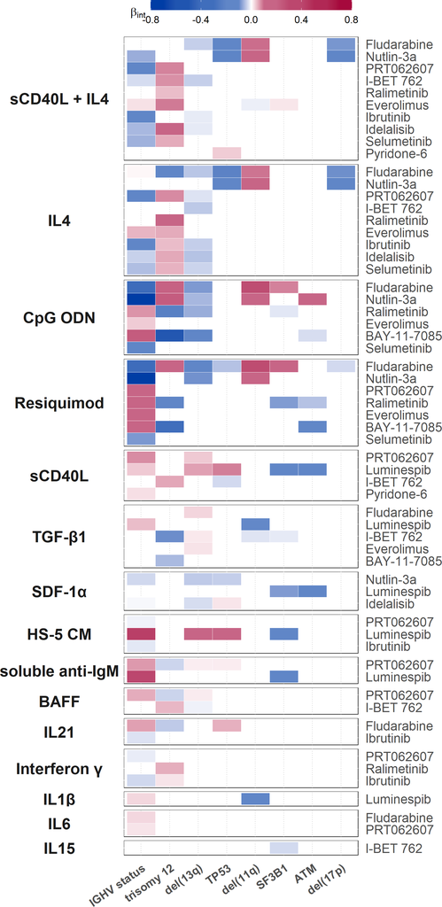

```r
#Plot heatmap
coeff.long.mat.ordered <-
  coeff.long.mat %>%
  dplyr::filter(gene %in% order_alt, coeff!=0) %>%
  dplyr::mutate(gene = factor(gene, levels = order_alt), int = factor(int, levels = rev(order_comb)))  %>%
  mutate(direction = ifelse(coeff>0, "Positive", "Negative")) %>%
  separate(int, sep=" \\+ ", into=c("Drug", "Stimulus"), remove = FALSE)

Order_Stim <-
  coeff.long.mat.ordered %>%
  dplyr::filter(coeff!=0) %>%
  dplyr::group_by(Stimulus) %>%
  dplyr::count(sort=T) %>%
  dplyr::select(Stimulus) %>%
  unlist()

Order_Drug <-
  coeff.long.mat.ordered %>%
  dplyr::filter(coeff!=0) %>%
  dplyr::group_by(Drug) %>%
  dplyr::count(sort=T) %>%
  dplyr::select(Drug) %>%
  unlist() %>%
  rev()

coeff.long.mat.ordered <-
  coeff.long.mat.ordered %>%
  mutate(Stimulus=factor(Stimulus, levels = Order_Stim),
         Drug=factor(Drug, levels = Order_Drug))


cyt_labels = c("TGF-b1"="TGF-\u03B21", "sCD40L+IL-4"="sCD40L + IL4", "IL-1b"="IL1\u03B2", "IL-4"="IL4", "IL-6"="IL6","IL-15"="IL15","IL-10"="IL10", "IL-21"="IL21","IL-2"="IL2", "Interferon gamma"= "Interferon \u03B3", "SDF-1a"="SDF-1\u03B1", "CpG ODN"="CpG ODN", "Resiquimod"="Resiquimod", "sCD40L"="sCD40L", "HS-5 CM"="HS-5 CM", "soluble anti-IgM"="soluble anti-IgM", "BAFF"="BAFF")

gene_labels = c("IGHV.status" = "IGHV status", "del11q" = "del(11q)", "del13q" = "del(13q)", "del17p" = "del(17p)", "trisomy12" = "trisomy 12", "TP53" = "TP53", "SF3B1" = "SF3B1", "ATM" = "ATM")


Fig6A <-
  coeff.long.mat.ordered %>%
  ggplot(aes(y=Drug, x=gene)) +
  geom_tile(aes(fill=coeff),color = "white") +
  scale_fill_gradientn(colors=c(rep(palblues[1:4],each=2),
                                "white",
                                rep(palreds[5:8], each=2)),
                       limits=c(-0.8,.8)) +
  t1 +
  theme(axis.text.x = element_text(angle = 35, hjust = 1, vjust = 1),
        axis.title.x = element_blank(),
        axis.title.y = element_blank(),
        axis.ticks = element_blank(),
        axis.ticks.x =element_blank(),
        panel.background = element_rect(color = "black", fill=NA),
        axis.line.x = element_blank(),
        axis.line.y = element_blank(),
        legend.key.height=unit(0.5, "cm"),
        legend.key.width=unit(2, "cm"),
        legend.title = element_text(face='bold', hjust = 0, size=fontsize+2),
        legend.position = "top",
        legend.key = element_blank(),
        legend.text = element_text(size=fontsize),
        legend.background = element_rect(color = NA),
        strip.text.y.left = element_text(size=22, angle = 0, face="bold"),
        strip.background = element_blank())+


  labs(fill = expression(beta["int"]))+
  scale_y_discrete(position = "right")+
  scale_x_discrete(labels = gene_labels) +
  facet_grid(Stimulus~., scales = "free_y",  space="free_y", switch = "both", labeller =labeller( Stimulus=cyt_labels))

Fig6A
```

### 1.9.2 Figure 6B

Predictor Profile of the size of interaction between Fludarabine and CpG ODN  
Generate all predictor profiles

```r
#run lassoPlot function to generate predictor profiles, with no minimum coefficient value
heatMaps <- lassoPlot(dataResult, geneMatrix.complete, betaMatrix, freqCut = 0.9, coefCut = 0.0)

heatMaps <- heatMaps[!is.na(heatMaps)]
```

Plot predictor profile for Fludarabine + CpG ODN

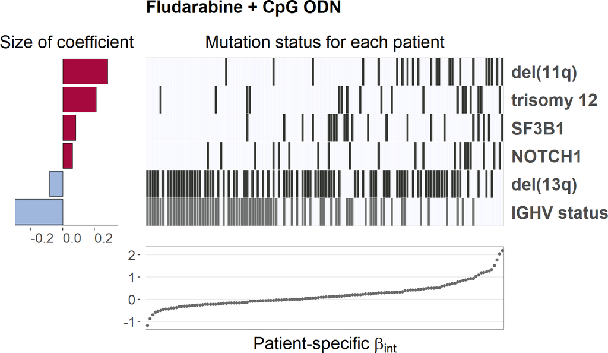

```r
Fig6B <- grid.arrange(grobs = heatMaps["Fludarabine + CpG ODN"], ncol = 1)
```

```r
Fig6B
```

### 1.9.3 Figure 6C

Fludarabine + CpG ODN viability values, faceted by IGHV status and trisomy 12 status

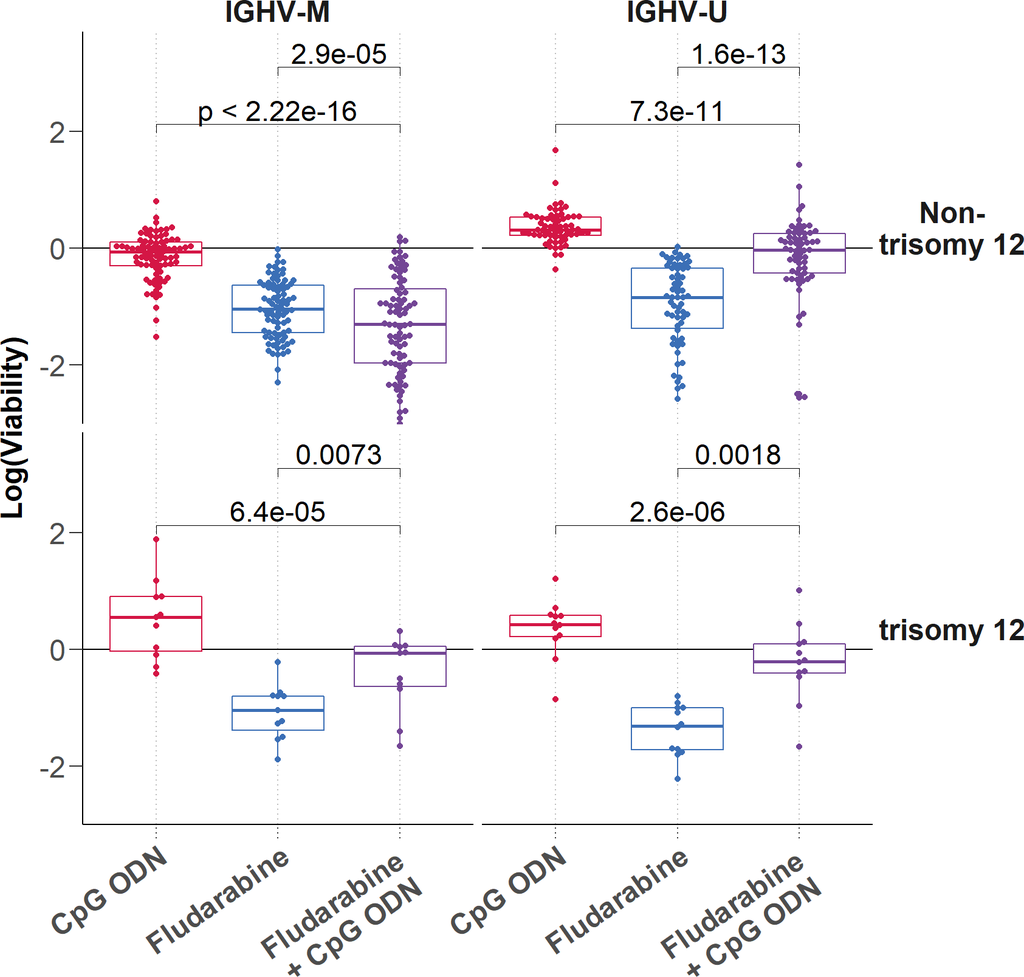

```r
#set facet labels
tri12.labs <- c("0" = "Non-\ntrisomy 12", "1" = "trisomy 12")
ighv.labs <- c("U" = "IGHV-U", "M" =  "IGHV-M")

#join viability and genetic data tables
df.patMeta <- left_join(df, patMeta, by = "PatientID")

Fig6C <-

  df.patMeta %>%
  #filter for drug:stimulus combinations of interest, make sure no NAs in genetic data
  dplyr::filter(DCK%in%c("DMSO:CpG ODN","Fludarabine:CpG ODN","Fludarabine:No Cytokine"),
                !is.na(trisomy12),
                !is.na(IGHV.status)) %>%
    mutate(DCK=factor(DCK, levels=c("DMSO:CpG ODN","Fludarabine:No Cytokine","Fludarabine:CpG ODN"))) %>%

  #plot treatment combination against viability
  ggplot(aes(x = DCK,y = Viability,color= DCK))+
  geom_hline(yintercept = 0)+
  geom_boxplot()+
  geom_beeswarm(cex=1.5) +
  guides(color="none", shape="none")+
  #add p values
  stat_compare_means(method = "t.test",
                     label.y.npc = 0.8,
                     paired = TRUE,
                     comparisons = list(c(1,3), c(2,3)),
                     step.increase=0.2,
                     size=6) +
  xlab("") +
  ylab("Log(Viability)") +
  #facet by trisomy 12 and IGHV status
  facet_grid(vars(trisomy12),
             vars(IGHV.status),
             labeller = labeller(trisomy12 = tri12.labs, IGHV.status = ighv.labs))+

  scale_x_discrete(labels=c("DMSO:CpG ODN"="CpG ODN",
                            "Fludarabine:No Cytokine"="Fludarabine",
                            "Fludarabine:CpG ODN"="Fludarabine \n+ CpG ODN "))+

  scale_color_manual(values=c(colors[4], colors[5],colors[3])) +
  scale_y_continuous(expand = expansion(mult = c(0, 0.1)))+
  t2 +
  theme(strip.background =element_rect(fill=NA),
        strip.text = element_text(size=fontsize+4, face="bold"),
        strip.text.y = element_text(angle = 0),
        axis.text.x = element_text(size=fontsize+4, angle = 35, hjust = 1, vjust = 1))

Fig6C
```

### 1.9.4 Figure 6D

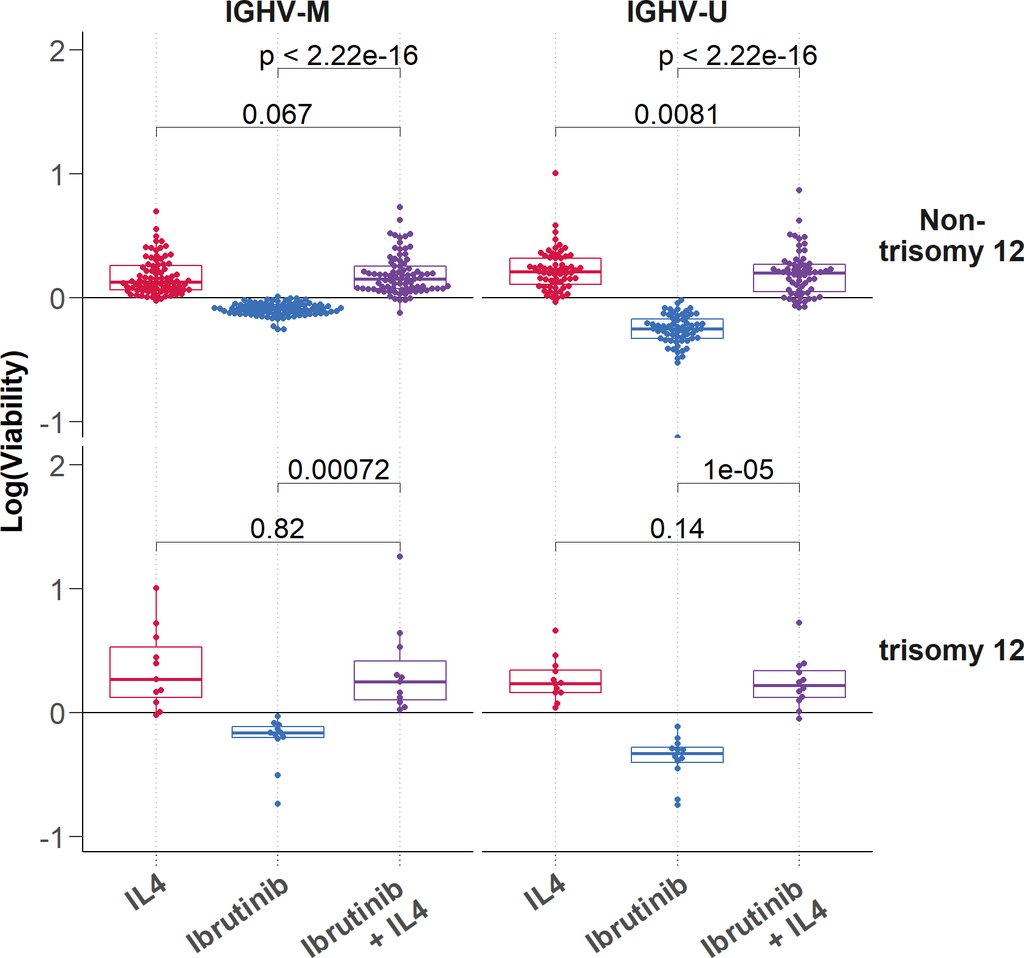

```r
Fig6D <-

  df.patMeta %>%
  #filter for drug:stimulus combinations of interest, make sure no NAs in genetic data
  dplyr::filter(DCK%in%c("DMSO:IL-4","Ibrutinib:IL-4","Ibrutinib:No Cytokine"),
                !is.na(trisomy12),
                !is.na(IGHV.status)) %>%
     mutate(DCK = factor(DCK, levels=c("DMSO:IL-4",
                                      "Ibrutinib:No Cytokine",
                                      "Ibrutinib:IL-4"))) %>%

  #plot treatment combination against viability
  ggplot(aes(x = DCK,y = Viability,color= DCK))+
  geom_hline(yintercept = 0)+
  geom_boxplot()+
  geom_beeswarm(cex=1.5) +
  guides(color="none", shape="none")+
  #add p values
  stat_compare_means(method = "t.test",
                     label.y.npc = 0.8,
                     paired = TRUE,
                     comparisons = list(c(1,3), c(2,3)),
                     step.increase=0.2,
                     size=6) +
  xlab("") +
  ylab("Log(Viability)") +
  #facet by trisomy 12 and IGHV status
  facet_grid(vars(trisomy12),
             vars(IGHV.status),
             labeller = labeller(trisomy12 = tri12.labs, IGHV.status = ighv.labs))+

  scale_x_discrete(labels=c("DMSO:IL-4"="IL4",
                            "Ibrutinib:No Cytokine"="Ibrutinib",
                            "Ibrutinib:IL-4"="Ibrutinib \n+ IL4"))+

  scale_color_manual(values=c(colors[4], colors[5], colors[3])) +
  scale_y_continuous(expand = expansion(mult = c(0, 0.1)))+
  t2 +
  theme(strip.background =element_rect(fill=NA),
        strip.text = element_text(size=fontsize+4, face="bold"),
        strip.text.y = element_text(angle = 0),
        axis.text.x = element_text(size=fontsize+4, angle = 35, hjust = 1, vjust = 1))

Fig6D
```

## 1.10 Save data

Save for use in supplementary script

```r
Lasso_Plots_Fig6 <- heatMaps
coeff.long.mat_Fig6 <- coeff.long.mat

save(Lasso_Plots_Fig6,
     coeff.long.mat_Fig6,
     file = "../../data/fig6_data_for_supplement.RData")
```

## 1.11 Assemble Figure

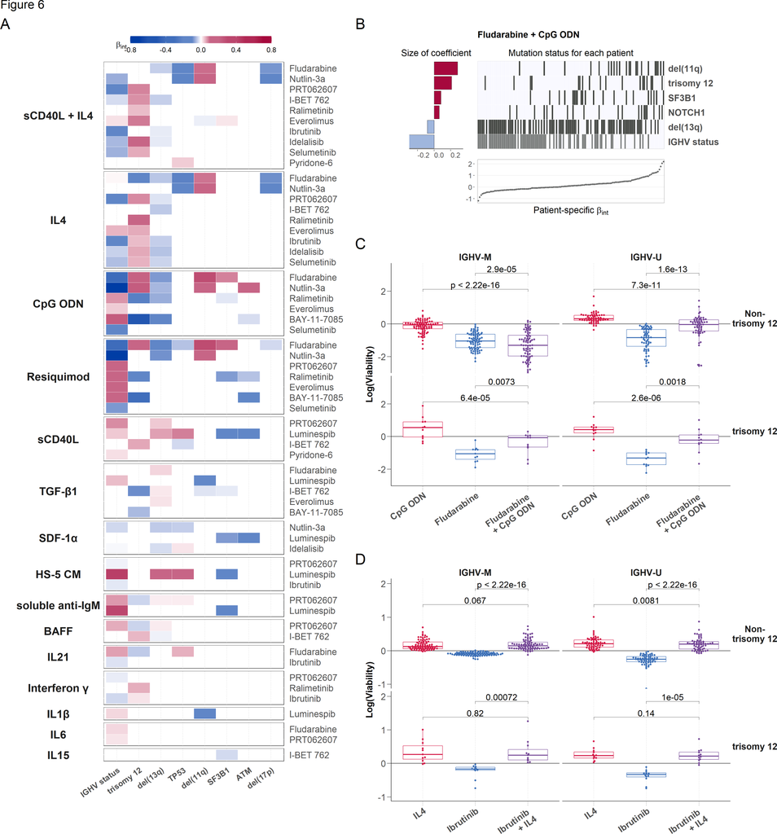

```r
#Design
design1<-"
  AB
  AC
  AD
"

#Tag Theme
tp <- theme(plot.tag=element_text(size = 30))

# Plot

Fig6<- (wrap_elements(Fig6A)) + tp +

Fig6B + tp +

Fig6C+ tp +

Fig6D + tp +

plot_annotation(tag_levels = "A", title="Figure 6", theme = theme(title=element_text(size = 20))) +

plot_layout(design=design1, heights = c(0.9,1,1))



Fig6
```

## 1.12 Appendix

```r
Sys.info()
```

```
##           sysname           release           version          nodename
##         "Windows"          "10 x64"     "build 19042" "DESKTOP-BF7AU2H"
##           machine             login              user    effective_user
##          "x86-64"      "PeterBruch"      "PeterBruch"      "PeterBruch"
```